# Data Driven Decision Making - The News Vendor Problem

### First DDDM assignment

José Pedro Pinto  
2019/2020 FCUP

## Introduction

In the real world it is, a lot of times, necessary to make decisions when there is randomness and uncertainty involved. How much to spend on insurance, when to go see a doctor, what the correct number of items in stock, how many tickets to sell, etc. constitute a few of such decisions. It is important to make the best decision we can, with whatever information we have. It is the goal of this assignment to make such decisions, by exploring possible solutions, implementing and testing.  
The assignment only pertains to a subset of all the problems, the subset in the news vendor problem.

### The news vendor problem

In the news vendor problem we have a set of factor which inform and weigh our decision.  
The base factor is the (unknown) demand, for example, the demand for a product dictates how much of it to have on stock, the demand for seats in a flight dictates how many tickets we can sell (not all customers might show to the flight).  
The two other important factors are the cost if we exceed the demand, and the cost if we don’t reach it (opportunity cost, how much we could have gained).  
Since it is not possible to exactly know the demand we want to pick the value that maximizes our gain, the one with the highest expected gain.  
In the classic news vendor problem the distribution of the values for demand is known, just not the actual values at any given point.

### Assignment specifics

For this particular project we have a data set with inventory values and sales.  
If the value of inventory is the same as the one for the sales it does not (necessarily) mean that the inventory was perfect, it means that the demands was at least as high as the number in inventory, possibly higher. That will have to be considered in the analysis.  
The final goal is to create the "order" function, which will dictate how many items to have in inventory, with the objective of maximizing profit.  
Having an item in inventory costs 9 per item, while selling has a revenue of 10, meaning a profit of 1.  
In this assignment, unlike in the classic problem, the distribution is not known and must also be inferred from the data.

### The order function

First and foremost, the final order function is presented here, for practical purposes and to ease the burden on the teacher.

```python
def order(past_moves, past_sales, market):
    """ function implementing a simple strategy; parameters:
        * past_sales: list with historical data for the market trend
        * market: function to evaluate the actual sales; 'market(value)' returns:
                - inventory, if smaller than demand (everything was sold)
                - true demand otherwise (i.e., some inventory wasn't sold)
    """
    import pandas as pd
    import numpy as np
    import math
    from statistics import mean
    from tensorflow.keras import backend
    from keras.models import Sequential
    from keras.layers import Dense
    from keras.layers import LSTM
    from keras.layers import Bidirectional
    from sklearn.preprocessing import MinMaxScaler

    # convert an array of values into a dataset matrix
    def create_dataset(dataset, look_back=1):
        dataX, dataY = [], []
        for i in range(len(dataset) - look_back - 1):
            #shift the data by lookback
            a = dataset[i:(i + look_back), 0]
            #add shifted data to X
            dataX.append(a)
            #add original data do Y
            dataY.append(dataset[i + look_back, 0])
        #return the X and Y data, with the past data and the intended prediction
        return np.array(dataX), np.array(dataY)

    #custom loss function for loss and profit
    def custom_cost_function(y, pred):
        #set cost of unsold item
        cost = 9
        #set profit of sold item
        profit = 1
        #get difference bettwen predicted value and real value
        diff = pred-y
        #return the amount of missed profit(cost for buying too much or too little)
        return backend.mean(abs(diff)*((backend.cast(diff>0,"float32"))*cost+(backend.cast(diff<=0,"float32"))*profit))

    #scale the train data as the LSTM is sensitive to scale
    scaler = MinMaxScaler(feature_range=(0, 1))
    train = scaler.fit_transform(np.asarray(past_sales).reshape(-1, 1))
    train = train.astype('float32')

    look_back = 1
    # reshape into X=t and Y=t+1
    trainX, trainY = create_dataset(train, look_back)

    # split into train and warmup sets
    train_size = int(len(trainX) * 0.95)
    trainX, warmX = trainX[0:train_size], trainX[train_size:len(trainX)]
    trainY, warmY = trainY[0:train_size], trainY[train_size:len(trainY)]

    # reshape input to be [samples, time steps, features]
    trainX = np.reshape(trainX, (trainX.shape[0], 1, trainX.shape[1]))
    warmX = np.reshape(warmX, (warmX.shape[0], 1, warmX.shape[1]))

    #number of models to train
    nmodels = 10
    models = []
    # create and fit the LSTM networks
    for i in range(0,nmodels):
        #print progress in training
        print("Model ",i+1)
        model = Sequential()
        #add input layer(LSTM)
        model.add(Bidirectional(LSTM(4, input_shape=(1, look_back))))
        #add output layer(dense, fully connected)
        model.add(Dense(1))
        #set loss function to custom loss function and optimiser
        model.compile(loss=custom_cost_function, optimizer='adam')
        #train the model
        model.fit(trainX, trainY, epochs=2, batch_size=1, verbose=2)
        #add model to the list of models
        models+=[model]

    #start model weights at equal values
    weights = [1]*len(models)
    #use warmup to set the weights for each model
    for i in range(0,len(warmX)):
        #scale the data as the LSTM is sensitive to scale
        sales = scaler.transform(trainY.reshape(-1, 1))
        totalWeight = sum(weights)
        move = 0
        moves = []
        #obtain predictions for all models
        for i in range(0,nmodels):
            #get the model
            model = models[i]
            #get the model weight
            weight = weights[i]

            #get the predicted move
            movei = model.predict(sales[-1].reshape(-1, 1, look_back))
            #scale it back to get the move in the right scale
            movei = scaler.inverse_transform(movei).reshape(1)[0]
            #update final move with this moves weight
            move += movei*(weight/totalWeight)
            #add move to the moves list
            moves += [movei]
        #round move to closest integer
        int(move+.5)
        #add sales to the previous sales
        np.append(trainY,[min(warmY[i],move)])
        #update the weights
        for i in range(0,nmodels):
            if(move == trainY[-1] and moves[i] > move):
                weights[i]+=1
            if(move > trainY[-1] and moves[i] < move):
                weights[i]+=1
        #increase previous sales value to bring moved predictions back up
        if move == trainY[-1]:
            trainY[-1] *= 1.1

    while True:
        sales = scaler.transform(np.asarray(past_sales).reshape(-1, 1))
        totalWeight = sum(weights)
        move = 0
        moves = []
        for i in range(0,nmodels):
            #get the predicted move
            model = models[i]
            #get the model weight
            weight = weights[i]

            #get the predicted move
            movei = model.predict(sales[-look_back:].reshape(-1, 1, look_back))
            #scale it back to get the move in the right scale
            movei = scaler.inverse_transform(movei).reshape(1)[0]
            #update final move with this moves weight
            move += movei*(weight/totalWeight)
            #add move to the moves list
            moves += [movei]
        #round move to closest integer
        int(move+.5)
        #send the move to market and get the number of sold items
        past_sales+=[market(move)]
        if past_sales[-1] == None:   # game over
            return
        #update the weights
        for i in range(0,nmodels):
            if(move == past_sales[-1] and moves[i] > move):
                weights[i]+=1
            if(move > past_sales[-1] and moves[i] < move):
                weights[i]+=1
        #increase previous sales value to bring moved predictions back up
        if move == past_sales[-1] :
            past_sales[-1] *=1.1
```

## The dataset

The dataset was provided by the teacher with the file name data-A01-2020.csv.  
Its origin is unknown, with it being possibly either a real or a simulated dataset.

### Import and plotting

With the intent of the understanding of the dataset it will be now imported and analyzed.  
Note: in order to run have the dataset on the same folder as the notebook.

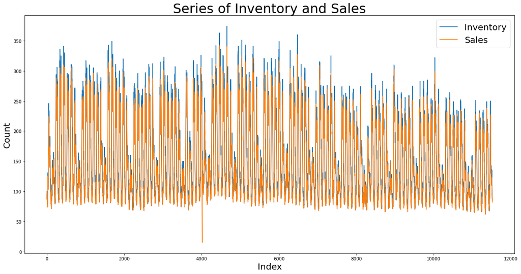

```python
import pandas as pd
import matplotlib.pyplot as plt
#obtain the data
df = pd.read_csv("data-A01-2020.csv", sep="\t")
#set the image size
plt.figure(figsize=(20,10))
#plot the data points
plt.plot(df["Inventory"],label="Inventory")
plt.plot(df["Sales"],label="Sales")
#format the plot
plt.title("Series of Inventory and Sales",fontsize = 30)
plt.xlabel("Index",fontsize = 20)
plt.ylabel("Count",fontsize = 20)
plt.legend(loc='upper right', prop={'size': 20})

plt.show()
```

There are a lot of entries in the data, in order to see more detail lets focus on the last 2000 observations.

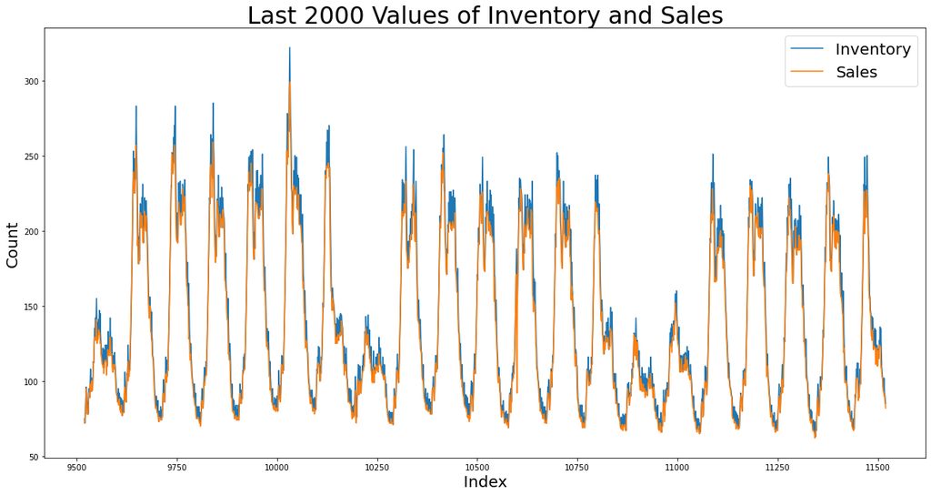

```python
#obtain last 2000 entries
dfLast2k = df[-2000:]
#set the image size
plt.figure(figsize=(20,10))
#plot the data points
plt.plot(dfLast2k["Inventory"],label="Inventory")
plt.plot(dfLast2k["Sales"],label="Sales")
#format the plot
plt.title("Last 2000 Values of Inventory and Sales",fontsize = 30)
plt.xlabel("Index",fontsize = 20)
plt.ylabel("Count",fontsize = 20)
plt.legend(loc='upper right', prop={'size': 20})

plt.show()
```

There are still a lot of entries in the data, in order to see more detail lets now focus on the last 200 observations.

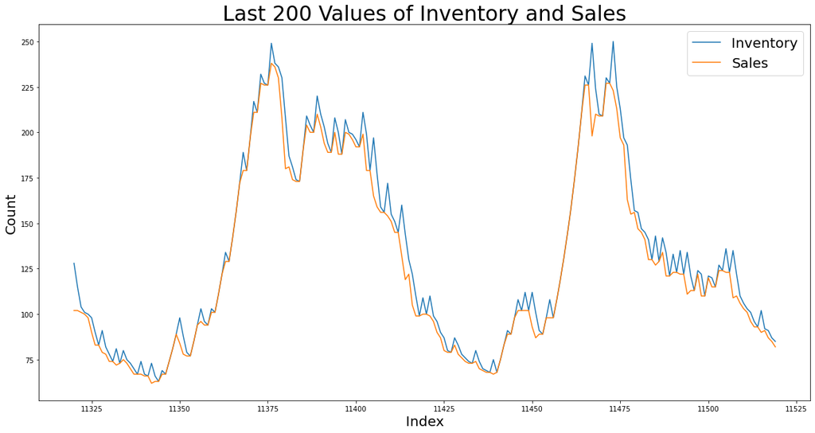

```python
#obtain last 200 entries
dfLast200 = df[-200:]
#set the image size
plt.figure(figsize=(20,10))
#plot the data points
plt.plot(dfLast200["Inventory"],label="Inventory")
plt.plot(dfLast200["Sales"],label="Sales")
#format the plot
plt.title("Last 200 Values of Inventory and Sales",fontsize = 30)
plt.xlabel("Index",fontsize = 20)
plt.ylabel("Count",fontsize = 20)
plt.legend(loc='upper right', prop={'size': 20})

plt.show()
```

Further analysis will be performed only on the sales data.

### ACF and Differentiation

With the intention of further exploring the seasonality we now plot the ACF (autocorrelation function) and difference the function.

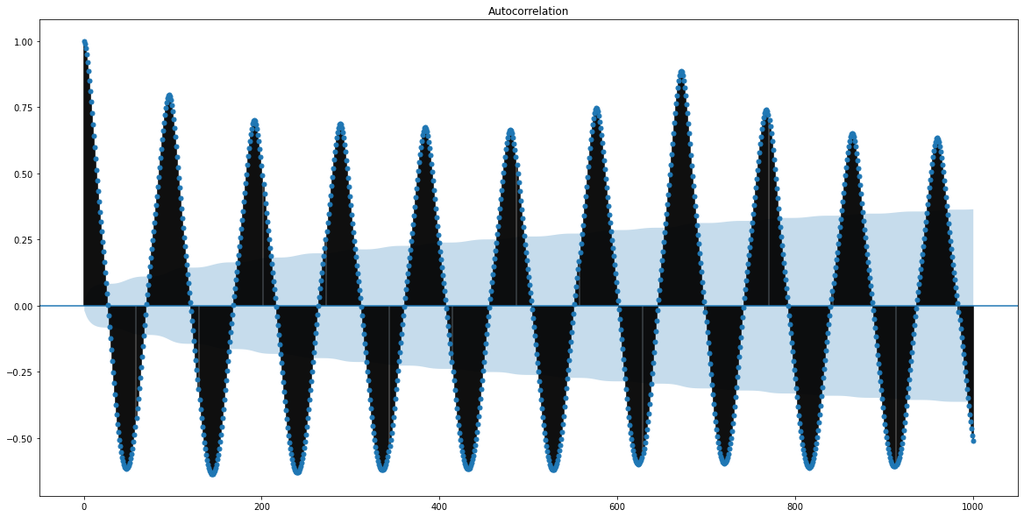

```python
from statsmodels.graphics.tsaplots import plot_acf
with plt.rc_context():
    #set the image size
    plt.rc("figure", figsize=(20,10))
    #plot the ACF of the data
    plot_acf(df["Sales"], lags=1000)
```

We can see that the peaks of the ACF occur exactly every 96 lags, as such there is a seasonality of lag 96.

Now we remove the found seasonality and do the plot once again to find weaker seasonalities.

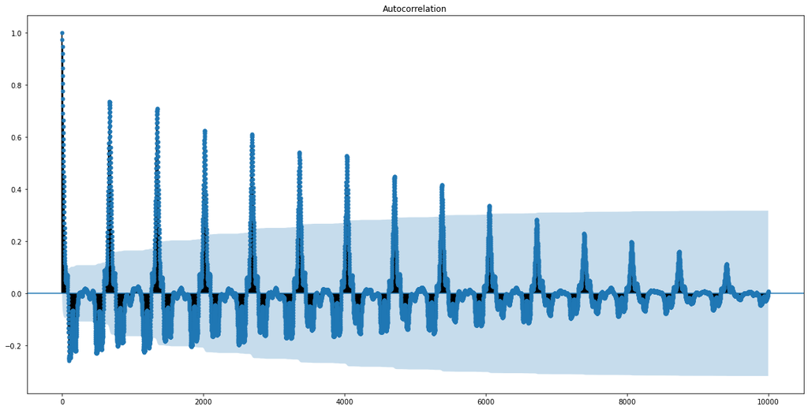

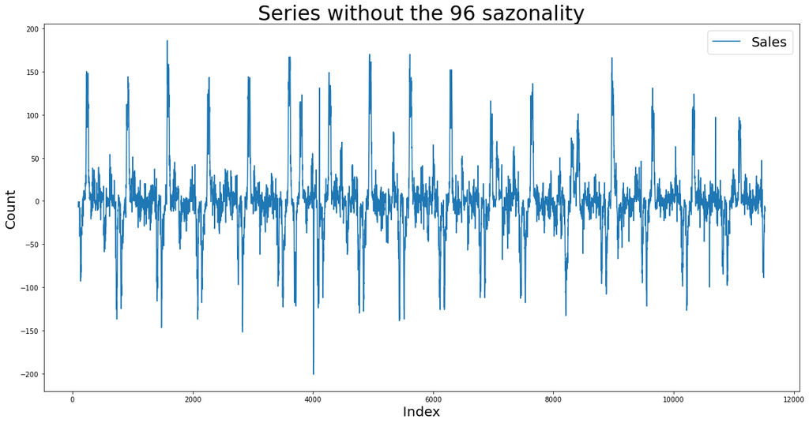

```python
#get the differenced series with lag 96
diffDF96 = df["Sales"].diff(96)[96:]

with plt.rc_context():
    #set the ACF image size
    plt.rc("figure", figsize=(20,10))
    #plot the ACF of the data
    plot_acf(diffDF96, lags=10000)

#set the image size
plt.figure(figsize=(20,10))
plt.plot(diffDF96,label="Sales")
#format the plot
plt.title("Series without the 96 sazonality",fontsize = 30)
plt.xlabel("Index",fontsize = 20)
plt.ylabel("Count",fontsize = 20)
plt.legend(loc='upper right', prop={'size': 20})

plt.show()
```

Now we once again remove the found seasonality and do the plot to find weaker seasonalities.

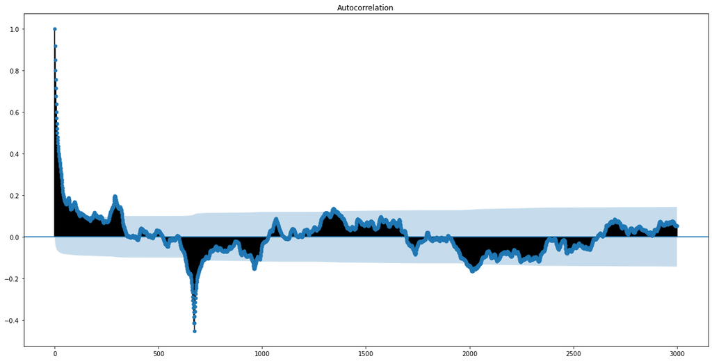

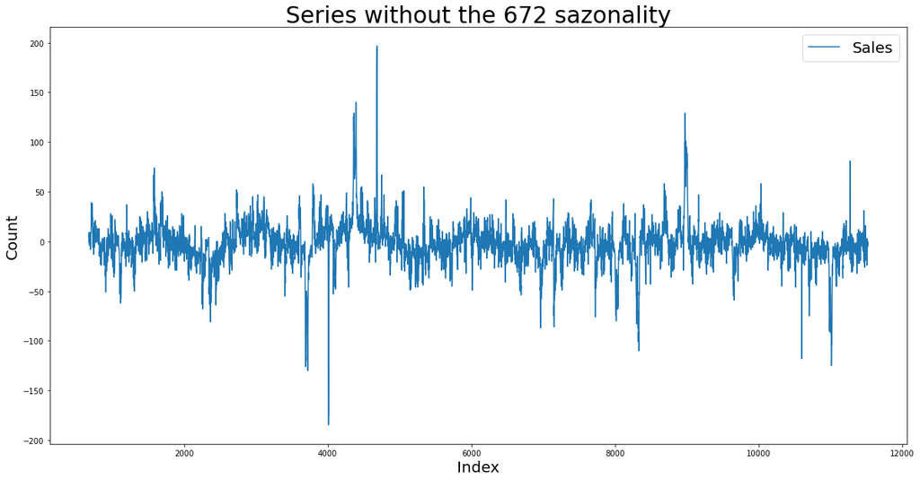

```python
#get the differenced series with lag 672
diffDF672 = df["Sales"].diff(672)[672:]

with plt.rc_context():
    #set the ACF image size
    plt.rc("figure", figsize=(20,10))
    #plot the ACF of the data
    plot_acf(diffDF672, lags=3000)

#set the image size
plt.figure(figsize=(20,10))
plt.plot(diffDF672,label="Sales")
#format the plot
plt.title("Series without the 672 sazonality",fontsize = 30)
plt.xlabel("Index",fontsize = 20)
plt.ylabel("Count",fontsize = 20)
plt.legend(loc='upper right', prop={'size': 20})

plt.show()
```

This time no strong singular seasonality is visible; however, the data is still not independent and there is some structure.  
This could indicate multiple small seasonalities.

## Evaluation

The performance of the models and solution to the problem will be evaluated with the following code.  
This code was provided by the teacher, with the only change being that the data that is being passed is the one analyzed before instead of the example data.  
The values passed to the order function are the same as in the previous data, but the demand passed is equal to the previous sales plus some noise. The noise is always positive and only added to the cases in which the inventory is equal to the sales.

```python
def evaluate(past_moves, past_sales, demand, gain, loss, order_fn):
    """ evaluate student's moves; parameters:
        * past_moves: history of past inventories
        * past_sales: history of past sales
        * demand: true future demand (unknown to students)
        * gain: profit per sold unit
        * loss: deficit generated per unit unsold
        * order_fn: function implementing student's method
    """
    moves = []
    def market(move):
        """ demand function ("censored", as it is limited by 'move'); parameter:
            * move: quantity available for selling (i.e., inventory)
        """
        global nmoves
        if nmoves >= len(demand):
            return None
        moves.append(move)
        sales = min(move, demand[nmoves])
        nmoves += 1
        return sales

    profit = 0
    n = len(demand)
    orders = []
    sales = []
    order_fn(past_moves, past_sales, market)

    for i in range(n):
        if moves[i] > demand[i]:
            profit += demand[i]*gain - (moves[i]-demand[i])*loss
        else:
            profit += moves[i]*gain
        #print(f"{i+1}\t{demand[i]}\t{moves[i]}\t{moves[i]-demand[i]}\t{profit}")
    return profit


if __name__ == "__main__":
    import pandas as pd
    import random
    #obtain the data
    df = pd.read_csv("data-A01-2020.csv", sep="\t")

    dff = df.copy()
    #add random noise to the future demand
    dff[dff["Sales"]==dff["Inventory"]]*=random.uniform(1,2)

    # split into train and test sets
    train_size = int(len(df) * 0.70)
    test_size = len(df) - train_size
    #get the past moves(data up to the train sample end)
    past_moves = df["Inventory"][0:train_size].to_list()
    #get the past sales(data up to the train sample end)
    past_sales = df["Sales"][0:train_size].to_list()
    #get the future demand(data starting at the train sample end)
    future_demand = dff["Sales"][train_size:len(df)].to_list()

    #set the gain and loss as presented in the project description
    gain = 1
    loss = 9
    nmoves = 0
    # from student1 import order as order_fn   # import student's order function
    order_fn = order
    profit = evaluate(past_moves, past_sales, future_demand, gain, loss, order_fn)
    print("profit", profit)
```

```
Model  1
 - 17s - loss: 0.0723
 - 15s - loss: 0.0461
Model  2
 - 16s - loss: 0.0559
 - 15s - loss: 0.0463
Model  3
 - 14s - loss: 0.0574
 - 14s - loss: 0.0455
Model  4
 - 13s - loss: 0.0588
 - 14s - loss: 0.0460
Model  5
 - 17s - loss: 0.0569
 - 15s - loss: 0.0457
Model  6
 - 14s - loss: 0.0626
 - 14s - loss: 0.0465
Model  7
 - 13s - loss: 0.0623
 - 13s - loss: 0.0461
Model  8
 - 14s - loss: 0.0607
 - 15s - loss: 0.0462
Model  9
 - 14s - loss: 0.0700
 - 12s - loss: 0.0458
Model  10
 - 14s - loss: 0.0655
 - 14s - loss: 0.0462
profit 371071.42357859935
```

## Order functions

Now the process of discovery, creation and tuning of the order function is explained and shown.

### Naive predictor

A naive and simple order function was provided by the teacher and will work as a baseline.

```python
def order(past_moves, past_sales, market):
    """ function implementing a simple strategy; parameters:
        * past_sales: list with historical data for the market trend
        * market: function to evaluate the actual sales; 'market(value)' returns:
                - inventory, if smaller than demand (everything was sold)
                - true demand otherwise (i.e., some inventory wasn't sold)
    """

    move = past_moves[-1]   # ignoring all data except last period
    sold = past_sales[-1]

    while True:
        if move == sold:
            move *= 1.1
        else:
            move = move*.9
            if move < sold:
                move = sold
        move = int(move+.5)   # round to closest integer
        # move = sold+1
        sold = market(move)
        if sold == None:   # game over
            return
```

The naive model consistently obtains profit around 290000 and this value will work as the base line.

### Naive predictor improved

Changing some of the values in the naive predictor we can obtain a significant improvement.

```python
def order(past_moves, past_sales, market):
    """ function implementing a simple strategy; parameters:
        * past_sales: list with historical data for the market trend
        * market: function to evaluate the actual sales; 'market(value)' returns:
                - inventory, if smaller than demand (everything was sold)
                - true demand otherwise (i.e., some inventory wasn't sold)
    """

    move = past_moves[-1]   # ignoring all data except last period
    sold = past_sales[-1]

    while True:
        if move == sold:
            move *= 1.05
        else:
            move = move*.7
            if move < sold:
                move = sold
        move = int(move+.5)   # round to closest integer
        # move = sold+1
        sold = market(move)
        if sold == None:   # game over
            return
```

The improved naive model achieves profits around 340000 which is substantially better than the previous naive model.  
An important thing to remember is that it is possibly overfitting the test set with the parameters.

### TBATS and BATS

Taking advantage of the knowledge that this is a time series with multiple seasonalities several models were tested.  
Firstly the TBATS and BATS models. Unfortunately, both of these are not ready to handle data of this size, not only taking an unpractical amount of time but also producing overflow and underflow errors.  
They are mentioned here only for the purpose of completeness and the code will not be shown.

### Sarimax with Fourier terms

After TBATS and BATS another model for time series with multiple seasonalities was tested.  
Sarimax is a well-known variant of SARIMA with extra terms for the predictions. these extra terms allow us to use the 2 seasonalities found.  
Good predictions were obtained; however, the model was considered too slow to be practically used. Therefore, the code will also not be presented.

### LSTM

LSTM (long short term memory) was the last and most effective model used.  
LSTM is a type of neural network for data series (text, video, etc.).  
A custom loss function was created and employed, with the intent of the function not maximizing the similarity to the data but instead maximizing profit.  
The model makes one step ahead forecast using the previous sales. As the sales less than the inventory the model will tend to a low constant, as such every time the sales and inventory are the same the previous the demand is multiplied by 1.1, to bring the prediction back up.

```python
def order(past_moves, past_sales, market):
    """ function implementing a simple strategy; parameters:
        * past_sales: list with historical data for the market trend
        * market: function to evaluate the actual sales; 'market(value)' returns:
                - inventory, if smaller than demand (everything was sold)
                - true demand otherwise (i.e., some inventory wasn't sold)
    """
    import pandas as pd
    import numpy as np
    import math
    from tensorflow.keras import backend
    from keras.models import Sequential
    from keras.layers import Dense
    from keras.layers import LSTM
    from keras.layers import Bidirectional
    from sklearn.preprocessing import MinMaxScaler

    # convert an array of values into a dataset matrix
    def create_dataset(dataset, look_back=1):
        dataX, dataY = [], []
        for i in range(len(dataset) - look_back - 1):
            #shift the data by lookback
            a = dataset[i:(i + look_back), 0]
            #add shifted data to X
            dataX.append(a)
            #add original data do Y
            dataY.append(dataset[i + look_back, 0])
        #return the X and Y data, with the past data and the intended prediction
        return np.array(dataX), np.array(dataY)

    #custom loss function for loss and profit
    def custom_cost_function(y, pred):
        #set cost of unsold item
        cost = 9
        #set profit of sold item
        profit = 1
        #get difference bettwen predicted value and real value
        diff = pred-y
        #return the amount of missed profit(cost for buying too much or too little)
        return backend.mean(abs(diff)*((backend.cast(diff>0,"float32"))*cost+(backend.cast(diff<=0,"float32"))*profit))

    #scale the train data as the LSTM is sensitive to scale
    scaler = MinMaxScaler(feature_range=(0, 1))
    train = scaler.fit_transform(np.asarray(past_sales).reshape(-1, 1))
    train = train.astype('float32')

    look_back = 1
    # reshape into X=t and Y=t+1
    trainX, trainY = create_dataset(train, look_back)

    # reshape input to be [samples, time steps, features]
    trainX = np.reshape(trainX, (trainX.shape[0], 1, trainX.shape[1]))

    # create and fit the LSTM network
    model = Sequential()
    #add input layer(LSTM)
    model.add(Bidirectional(LSTM(10, input_shape=(1, look_back))))
    #add output layer(dense, fully connected)
    model.add(Dense(1))
    #set loss function to custom loss function and optimiser
    model.compile(loss=custom_cost_function, optimizer='adam')
    #train the model
    model.fit(trainX, trainY, epochs=5, batch_size=1, verbose=2)

    while True:
        #scale the data as the LSTM is sensitive to scale
        sales = scaler.transform(np.asarray(past_sales).reshape(-1, 1))
        #get the predicted move
        move = model.predict(sales[-1].reshape(-1, 1, look_back))
        #scale it back to get the move in the right scale
        move = scaler.inverse_transform(move).reshape(1)[0]
        #round move to closest integer
        int(move+.5)
        #send the move to market and get the number of sold items
        newSold = market(move)
        past_sales+=[newSold]
        #increase previous sales value to bring moved predictions back up
        if move == newSold:
            past_sales[-1] *= 1.1
        if newSold == None:   # game over
            return
```

The model has good results but also high variability, with the profit fluctuating between 300000 and 370000.

### LSTM ensemble

In order to improve the performance of the previous method and reduce variability an ensemble was created.  
10 models were trained, and the final prediction is a weighed sum of them.  
Every time a prediction is made the weights are updated. When the predictions start the weights have still not been tuned, which leads to worse results, as such a warmup set of 5% was created.

```python
def order(past_moves, past_sales, market):
    """ function implementing a simple strategy; parameters:
        * past_sales: list with historical data for the market trend
        * market: function to evaluate the actual sales; 'market(value)' returns:
                - inventory, if smaller than demand (everything was sold)
                - true demand otherwise (i.e., some inventory wasn't sold)
    """
    import pandas as pd
    import numpy as np
    import math
    from statistics import mean
    from tensorflow.keras import backend
    from keras.models import Sequential
    from keras.layers import Dense
    from keras.layers import LSTM
    from keras.layers import Bidirectional
    from sklearn.preprocessing import MinMaxScaler

    # convert an array of values into a dataset matrix
    def create_dataset(dataset, look_back=1):
        dataX, dataY = [], []
        for i in range(len(dataset) - look_back - 1):
            #shift the data by lookback
            a = dataset[i:(i + look_back), 0]
            #add shifted data to X
            dataX.append(a)
            #add original data do Y
            dataY.append(dataset[i + look_back, 0])
        #return the X and Y data, with the past data and the intended prediction
        return np.array(dataX), np.array(dataY)

    #custom loss function for loss and profit
    def custom_cost_function(y, pred):
        #set cost of unsold item
        cost = 9
        #set profit of sold item
        profit = 1
        #get difference bettwen predicted value and real value
        diff = pred-y
        #return the amount of missed profit(cost for buying too much or too little)
        return backend.mean(abs(diff)*((backend.cast(diff>0,"float32"))*cost+(backend.cast(diff<=0,"float32"))*profit))

    #scale the train data as the LSTM is sensitive to scale
    scaler = MinMaxScaler(feature_range=(0, 1))
    train = scaler.fit_transform(np.asarray(past_sales).reshape(-1, 1))
    train = train.astype('float32')

    look_back = 1
    # reshape into X=t and Y=t+1
    trainX, trainY = create_dataset(train, look_back)

    # split into train and warmup sets
    train_size = int(len(trainX) * 0.95)
    trainX, warmX = trainX[0:train_size], trainX[train_size:len(trainX)]
    trainY, warmY = trainY[0:train_size], trainY[train_size:len(trainY)]

    # reshape input to be [samples, time steps, features]
    trainX = np.reshape(trainX, (trainX.shape[0], 1, trainX.shape[1]))
    warmX = np.reshape(warmX, (warmX.shape[0], 1, warmX.shape[1]))

    #number of models to train
    nmodels = 10
    models = []
    # create and fit the LSTM networks
    for i in range(0,nmodels):
        #print progress in training
        print("Model ",i+1)
        model = Sequential()
        #add input layer(LSTM)
        model.add(Bidirectional(LSTM(4, input_shape=(1, look_back))))
        #add output layer(dense, fully connected)
        model.add(Dense(1))
        #set loss function to custom loss function and optimiser
        model.compile(loss=custom_cost_function, optimizer='adam')
        #train the model
        model.fit(trainX, trainY, epochs=2, batch_size=1, verbose=2)
        #add model to the list of models
        models+=[model]

    #start model weights at equal values
    weights = [1]*len(models)
    #use warmup to set the weights for each model
    for i in range(0,len(warmX)):
        #scale the data as the LSTM is sensitive to scale
        sales = scaler.transform(trainY.reshape(-1, 1))
        totalWeight = sum(weights)
        move = 0
        moves = []
        #obtain predictions for all models
        for i in range(0,nmodels):
            #get the model
            model = models[i]
            #get the model weight
            weight = weights[i]

            #get the predicted move
            movei = model.predict(sales[-1].reshape(-1, 1, look_back))
            #scale it back to get the move in the right scale
            movei = scaler.inverse_transform(movei).reshape(1)[0]
            #update final move with this moves weight
            move += movei*(weight/totalWeight)
            #add move to the moves list
            moves += [movei]
        #round move to closest integer
        int(move+.5)
        #add sales to the previous sales
        np.append(trainY,[min(warmY[i],move)])
        #update the weights
        for i in range(0,nmodels):
            if(move == trainY[-1] and moves[i] > move):
                weights[i]+=1
            if(move > trainY[-1] and moves[i] < move):
                weights[i]+=1
        #increase previous sales value to bring moved predictions back up
        if move == trainY[-1]:
            trainY[-1] *= 1.1

    while True:
        sales = scaler.transform(np.asarray(past_sales).reshape(-1, 1))
        totalWeight = sum(weights)
        move = 0
        moves = []
        for i in range(0,nmodels):
            #get the predicted move
            model = models[i]
            #get the model weight
            weight = weights[i]

            #get the predicted move
            movei = model.predict(sales[-look_back:].reshape(-1, 1, look_back))
            #scale it back to get the move in the right scale
            movei = scaler.inverse_transform(movei).reshape(1)[0]
            #update final move with this moves weight
            move += movei*(weight/totalWeight)
            #add move to the moves list
            moves += [movei]
        #round move to closest integer
        int(move+.5)
        #send the move to market and get the number of sold items
        past_sales+=[market(move)]
        if past_sales[-1] == None:   # game over
            return
        #update the weights
        for i in range(0,nmodels):
            if(move == past_sales[-1] and moves[i] > move):
                weights[i]+=1
            if(move > past_sales[-1] and moves[i] < move):
                weights[i]+=1
        #increase previous sales value to bring moved predictions back up
        if move == past_sales[-1] :
            past_sales[-1] *=1.1
```

With the ensemble the variability was reduced and we can now consistently obtain 370000 of profit.

# Further Work

There are a lot od ideas and strategies that were thought of but were never employed and tested. Some of those are presented here.

Some of the previously tryed models, BATS, TBATS and SARIMAX where not up to the task and were discarder, however there is the possibility that these could be made to work. Restricting the training data to the last big cycle would reduce greatly the amount of data and as such the training time, wich could make these models feasible. Subsampling the data would also be a possibility, only getting a value every 5 or 10 for example, this would lead, however, to the requirement that the prediction are the same for the size of the subsampling.

Another method that was though of but not employed is the fitting of a sum of trigonometric functions to the data. These would catch the most important seasonalities. Another model would focus on the errors of the trigonometric function, for example the LSTM. This woul constitute a type of boosting. With the function creating the baseline and the extra model the details, the problem of the LSTM slipping lower and lower would be resolved without a fixed multiplier, which would probably lead to better results.

# Conclusions

The news vendor problem is not simple, and a myriad of options and solutions exist. We must be careful with our assumptions and estimations, even though both must be done to obtain the best performance. The assumption that the data will present itself in a similar way in the future to what happened in the past is an important one, and the models used rely on that. If that assumption does not hold to a reasonable degree, then the models will be worse than the naive model that makes no such assumption.

Typical time series models do not work well on data of this dimension, with SARIMAX, BATS and TBATS all failing to complete the task. On the other hand, neural network models work quite well, which is the reason why they are so often used in big data tasks, with a good balance of efficiency and efficacy.

There is a lot of improvement room which would be possible to achieve given more time and resources. However, the results obtained were more than acceptable.

## References

[1] https://medium.com/intive-developers/forecasting-time-series-with-multiple-seasonalities-using-tbats-in-python-398a00ac0e8a  
[2] https://machinelearningmastery.com/time-series-prediction-lstm-recurrent-neural-networks-python-keras/